# Genre Coherence in Spotify’s Audio Feature Space

STAT 4710/5710 — Modern Data Mining, Spring 2026

Sung Cho, Etienne Lee, Leo Li

2026-04-27

## Introduction and Motivation

Genre is one of the most fundamental organizing principles in music. Streaming platforms like Spotify use genre labels to drive recommendation algorithms, playlist curation, and discovery features. Yet the boundary between genres has always been porous: artists blend styles, listeners resist categorization, and industry labels often reflect marketing logic rather than musical content. This project uses Spotify’s audio feature API — a set of continuous measurements derived from signal processing — to ask a concrete question: do songs within the same genre actually sound similar to each other?

We approach this question from five angles: unsupervised clustering (does the audio feature space cluster into genre-like groups?), within-genre variance (which genres are musically tight vs. diffuse?), popularity regression (does genre predict popularity beyond what audio features explain?), boundary song detection (which songs are misclassified by a genre classifier, and what does that reveal?), and feature importance (which audio dimensions drive genre separation vs. popularity?). Together these form a comprehensive audit of Spotify’s genre taxonomy.

## Data Description

The dataset is the [Spotify Tracks Dataset](https://www.kaggle.com/datasets/maharshipandya/-spotify-tracks-dataset) from Kaggle (author: maharshipandya), comprising approximately 114,000 tracks across 125 fine-grained genres. Each row corresponds to a unique track with 20 columns: metadata (track ID, artist, album, name), one outcome variable (`popularity`, scored 0–100 based on recent play counts), three discrete audio features (`key`, `mode`, `time_signature`), and ten continuous audio features that form our primary feature matrix.

The ten continuous features used throughout this analysis are: `danceability`, `energy`, `loudness`, `speechiness`, `acousticness`, `instrumentalness`, `liveness`, `valence`, `tempo`, and `duration_ms`. The discrete features (`key`, `mode`, `time_signature`) are excluded from the primary feature matrix but are explored in EDA. After removing duplicate track IDs and rows with missing values in the audio features, the cleaned dataset contains 89741 tracks across 113 genres.

We map the 125 fine-grained genres to 11 macro-genre families (e.g., Pop, Rock/Metal, Electronic/Dance) to enable higher-level comparisons and visualizations. Any genres not covered by the mapping are labeled “Other.”

```r
tibble(
  Statistic = c("Total tracks (after dedup & NA removal)",
                "Unique fine-grained genres",
                "Unique macro-genres",
                "Features in primary matrix"),
  Value = c(nrow(spotify),
            n_distinct(spotify$track_genre),
            n_distinct(spotify$macro_genre),
            length(audio_features))
) %>%
  kable(caption = "Dataset summary after preprocessing") %>%
  kable_styling(bootstrap_options = c("striped", "hover"), full_width = FALSE)
```

Dataset summary after preprocessing

| Statistic | Value |
| --- | --- |
| Total tracks (after dedup & NA removal) | 89741 |
| Unique fine-grained genres | 113 |
| Unique macro-genres | 11 |
| Features in primary matrix | 10 |

## Exploratory Data Analysis

We begin with univariate and bivariate summaries of the audio features and genre distribution to understand the data structure before modeling.

### Distributions of Audio Features and Popularity

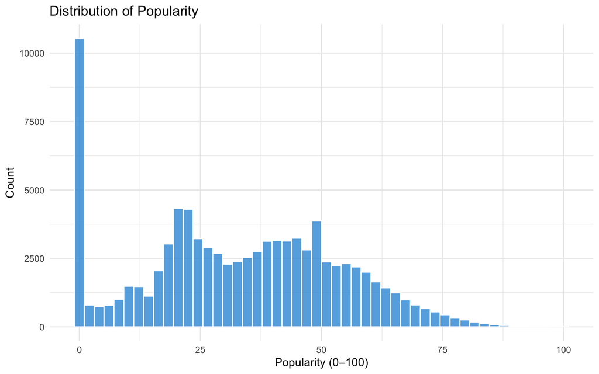

Distributions of popularity and the 10 audio features. Note the spike at popularity = 0 and the strong bimodality of instrumentalness.

```r
# Popularity histogram
p_pop <- ggplot(spotify, aes(x = popularity)) +
  geom_histogram(bins = 50, fill = "#3498db", color = "white", alpha = 0.8) +
  labs(title = "Distribution of Popularity", x = "Popularity (0–100)", y = "Count") +
  theme_minimal()

# Audio feature density plots
spotify_long <- spotify %>%
  select(all_of(audio_features)) %>%
  pivot_longer(everything(), names_to = "feature", values_to = "value")

p_features <- ggplot(spotify_long, aes(x = value)) +
  geom_histogram(bins = 40, fill = "#2ecc71", color = "white", alpha = 0.8) +
  facet_wrap(~feature, scales = "free", ncol = 5) +
  labs(title = "Distributions of Audio Features", x = NULL, y = "Count") +
  theme_minimal() +
  theme(strip.text = element_text(size = 9))

print(p_pop)
```

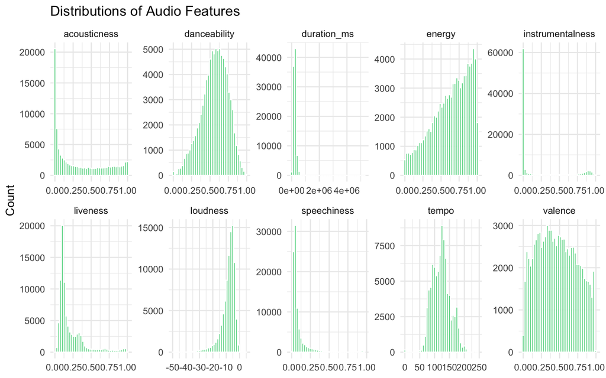

Distributions of popularity and the 10 audio features. Note the spike at popularity = 0 and the strong bimodality of instrumentalness.

```r
print(p_features)
```

The `popularity` distribution is right-skewed with a pronounced spike at 0, reflecting the large number of obscure tracks. `instrumentalness` is highly bimodal: most tracks are either strongly vocal or strongly instrumental with few intermediate values. `speechiness` and `acousticness` are also right-skewed.

### Correlation Structure

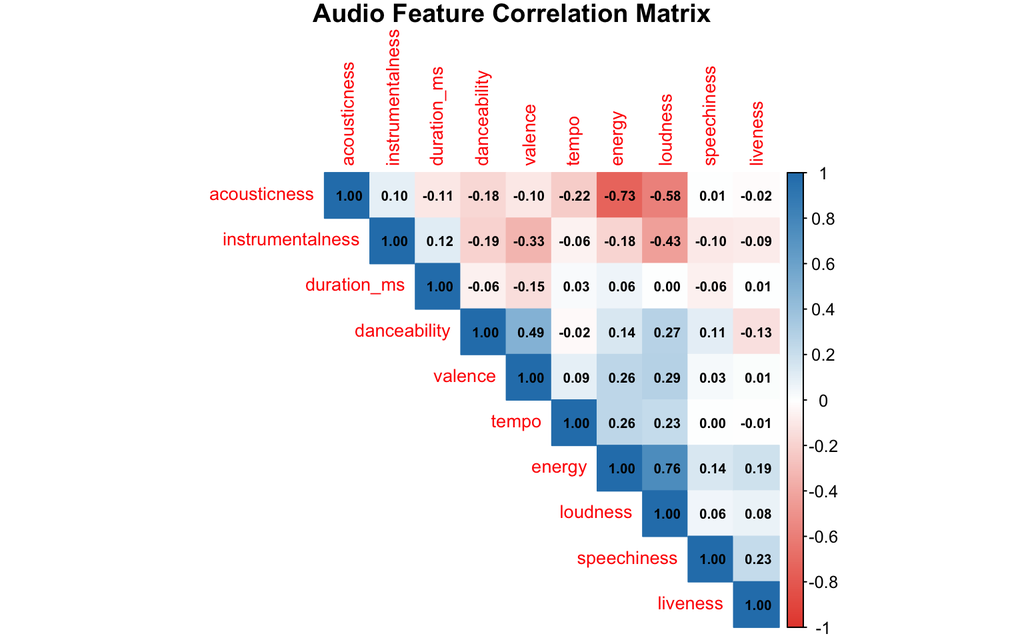

Correlation matrix of the 10 audio features. Strong positive correlation between energy and loudness; strong negative correlation between energy and acousticness.

```r
cor_mat <- cor(spotify %>% select(all_of(audio_features)), use = "complete.obs")

corrplot(cor_mat,
         method = "color",
         type = "upper",
         order = "hclust",
         tl.cex = 0.85,
         addCoef.col = "black",
         number.cex = 0.65,
         col = colorRampPalette(c("#e74c3c", "white", "#2980b9"))(200),
         title = "Audio Feature Correlation Matrix",
         mar = c(0, 0, 1, 0))
```

### Genre Counts by Macro-Genre

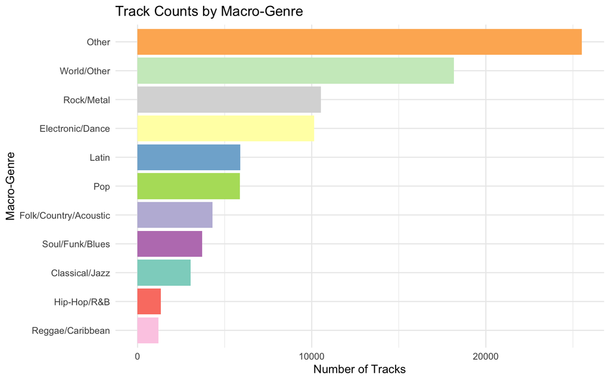

Track counts by macro-genre. Some macro-genre families are substantially larger than others, reflecting the original dataset composition.

```r
spotify %>%
  group_by(macro_genre) %>%
  summarise(n = n(), .groups = "drop") %>%
  arrange(desc(n)) %>%
  ggplot(aes(x = reorder(macro_genre, n), y = n, fill = macro_genre)) +
  geom_col(show.legend = FALSE) +
  coord_flip() +
  scale_fill_brewer(palette = "Set3") +
  labs(title = "Track Counts by Macro-Genre",
       x = "Macro-Genre", y = "Number of Tracks") +
  theme_minimal()
```

### Audio Fingerprint by Macro-Genre (Radar Chart)

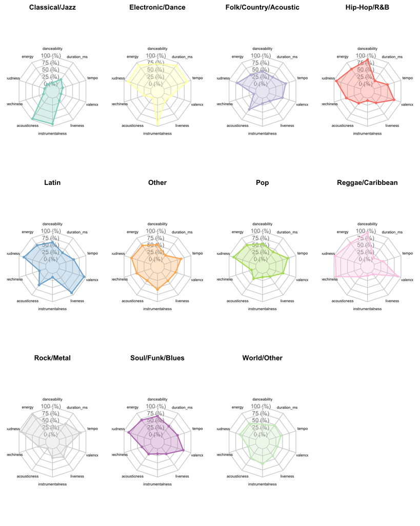

Radar charts showing the mean standardized audio profile (‘fingerprint’) for each macro-genre family.

```r
# Compute mean standardized features per macro-genre
radar_data <- as_tibble(X_scaled) %>%
  mutate(macro_genre = spotify$macro_genre) %>%
  group_by(macro_genre) %>%
  summarise(across(everything(), mean), .groups = "drop")

genres_list <- levels(spotify$macro_genre)

# Radar chart requires max/min rows prepended
radar_mat <- radar_data %>%
  select(-macro_genre) %>%
  as.data.frame()
rownames(radar_mat) <- radar_data$macro_genre

max_vals <- apply(radar_mat, 2, max) + 0.1
min_vals <- apply(radar_mat, 2, min) - 0.1
radar_plot_data <- rbind(max_vals, min_vals, radar_mat)

par(mfrow = c(3, 4), mar = c(1, 1, 2, 1))
colors_radar <- RColorBrewer::brewer.pal(min(nrow(radar_mat), 11), "Set3")
for (i in seq_len(nrow(radar_mat))) {
  fmsb::radarchart(
    radar_plot_data[c(1, 2, i + 2), ],
    axistype = 1,
    pcol = colors_radar[(i - 1) %% length(colors_radar) + 1],
    pfcol = adjustcolor(colors_radar[(i - 1) %% length(colors_radar) + 1], alpha.f = 0.3),
    plwd = 2,
    cglcol = "grey80",
    cglty = 1,
    axislabcol = "grey50",
    vlcex = 0.65,
    title = rownames(radar_mat)[i]
  )
}
par(mfrow = c(1, 1))
```

### Popularity by Macro-Genre

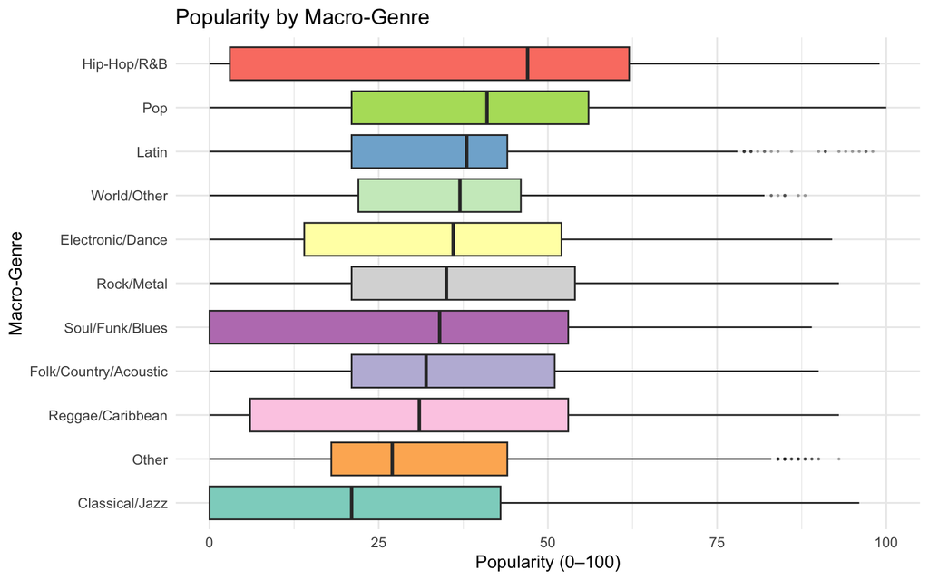

Distribution of popularity scores by macro-genre. Pop and Hip-Hop/R&B tend to have higher median popularity; Classical/Jazz and Electronic/Dance show wider variance.

```r
ggplot(spotify, aes(x = reorder(macro_genre, popularity, median),
                    y = popularity, fill = macro_genre)) +
  geom_boxplot(outlier.size = 0.3, outlier.alpha = 0.3, show.legend = FALSE) +
  coord_flip() +
  scale_fill_brewer(palette = "Set3") +
  labs(title = "Popularity by Macro-Genre",
       x = "Macro-Genre", y = "Popularity (0–100)") +
  theme_minimal()
```

Popularity differs meaningfully across macro-genres, with Hip-Hop/R&B showing the highest median popularity at roughly 47, followed by Pop at about 41, while Latin, World/Other, and Electronic/Dance cluster in the middle around the mid-30s to high-30s. At the lower end, Classical/Jazz has the lowest median, near 20, and Other is also relatively low at around 27. In terms of spread, several genres show substantial variability: Hip-Hop/R&B, Pop, and Electronic/Dance have wide interquartile ranges and long upper whiskers, suggesting these categories contain both many low-visibility songs and a meaningful number of breakout tracks. Latin and Other also display notable high-end outliers, with some songs reaching the 80–95 range despite having lower central tendency overall. By contrast, Classical/Jazz is concentrated at lower popularity levels and appears less likely to produce extremely popular tracks. Qualitatively, this pattern matches streaming behavior: mainstream, playlist-driven genres such as Hip-Hop/R&B and Pop tend to dominate mass listening and algorithmic discovery, while genres like Classical/Jazz or Folk/Country/Acoustic may have more niche but stable audiences, leading to lower medians even when a few songs still achieve broad reach.

## Methods

This section describes the five analytical angles applied to the dataset. All methods operate on the standardized 10-feature matrix unless otherwise noted.

### PCA and Clustering

We use PCA to project the 10-dimensional audio feature space into a lower-dimensional space for visualization and as input to clustering. K-means and hierarchical clustering are then applied to assess whether unsupervised groupings align with genre labels.

### Popularity Regression

We model `popularity` as a function of audio features and macro-genre dummies using OLS, lasso (global), and stratified OLS per macro-genre. This tests whether genre labels carry market value beyond what audio features explain.

### Boundary Song Detection

A random forest classifier is trained to predict macro-genre from audio features. Tracks where the true genre receives low predicted probability — while another genre receives the highest probability — are termed “boundary songs” and reveal where genre assignments are musically ambiguous.

### Feature Importance

We synthesize classifier variable importance (random forest) with lasso coefficient magnitudes to ask which audio dimensions drive genre separation vs. popularity prediction.

### Audio Feature Geometry

Inspired by word2vec-style vector arithmetic, we define interpretable axes in the 10-dimensional audio feature space by computing normalized direction vectors between pairs of maximally distinct genre centroids. Projecting all genre centroids onto these axes tests whether the space has semantic directionality — genres sorting sensibly along acoustic, vocal, and intensity dimensions — even in the absence of clean cluster separation.

## Results

### Angle 1: PCA and Clustering

#### PCA

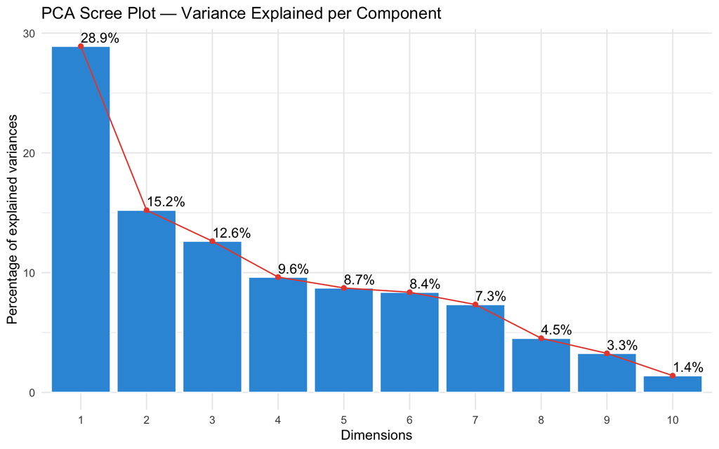

Left: Scree plot showing variance explained by each principal component. Right: PCA biplot of PC1 vs. PC2 colored by macro-genre.

```r
set.seed(42)

pca_fit <- prcomp(X_scaled, scale. = FALSE)  # already standardized

# Scree plot
fviz_screeplot(pca_fit, addlabels = TRUE, ncp = 10,
               barfill = "#3498db", barcolor = "white",
               linecolor = "#e74c3c") +
  labs(title = "PCA Scree Plot — Variance Explained per Component") +
  theme_minimal()
```

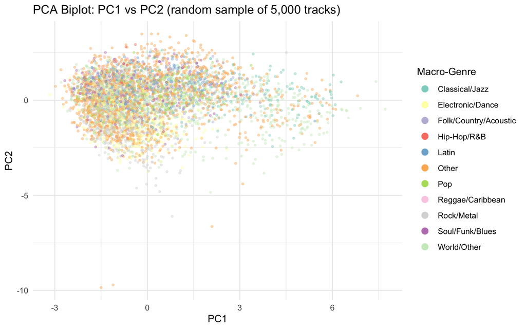

Left: Scree plot showing variance explained by each principal component. Right: PCA biplot of PC1 vs. PC2 colored by macro-genre.

```r
# Biplot PC1 vs PC2
pca_scores <- as_tibble(pca_fit$x) %>%
  mutate(macro_genre = spotify$macro_genre)

ggplot(pca_scores %>% sample_n(5000), aes(x = PC1, y = PC2, color = macro_genre)) +
  geom_point(alpha = 0.4, size = 0.8) +
  scale_color_brewer(palette = "Set3") +
  labs(title = "PCA Biplot: PC1 vs PC2 (random sample of 5,000 tracks)",
       color = "Macro-Genre") +
  theme_minimal() +
  guides(color = guide_legend(override.aes = list(size = 3, alpha = 1)))
```

```r
# Cumulative variance explained
cum_var <- cumsum(pca_fit$sdev^2) / sum(pca_fit$sdev^2)
tibble(
  Components = c(2, 3, 5, 10),
  `Cumulative Variance Explained` = scales::percent(cum_var[c(2, 3, 5, 10)])
) %>%
  kable(caption = "Cumulative variance explained by PCA components") %>%
  kable_styling(bootstrap_options = c("striped", "hover"), full_width = FALSE)
```

Cumulative variance explained by PCA components

| Components | Cumulative Variance Explained |
| --- | --- |
| 2 | 44% |
| 3 | 57% |
| 5 | 75% |
| 10 | 100% |

The PCA results show that the first few components capture a substantial share of the variation in Spotify audio features, but not enough to reduce the genre structure to just one or two clean dimensions. Quantitatively, PC1 explains 28.9% of the total variance and PC2 explains 15.2%, so the first two components together account for about 44% of the variation. Expanding further, the first 3 PCs explain 57%, and the first 5 PCs explain 75%, which suggests that the dataset has meaningful lower-dimensional structure, but that this structure is still moderately high-dimensional rather than dominated by a single latent axis. The scree plot shows a clear drop after the first component and then a more gradual decline, indicating that PC1 is especially important, while PCs 2–5 still each contribute nontrivially. Qualitatively, however, the PC1-versus-PC2 biplot shows substantial overlap across macro-genres, with no sharply separated clusters. Some genres appear to drift toward different regions—for example, World/Other and Classical/Jazz extend further to the right on PC1, while several mainstream genres such as Pop, Hip-Hop/R&B, Latin, and Electronic/Dance concentrate more heavily near the center-left—but the boundaries remain highly diffuse. Overall, the PCA suggests that while audio features do contain structured variation, the first two principal components do not visually separate macro-genres cleanly, which is early evidence that Spotify genre labels may overlap considerably in underlying musical feature space.

#### UMAP Projection

Unlike PCA, which finds the linear directions of maximum variance, UMAP (Uniform Manifold Approximation and Projection) preserves local neighborhood structure in a non-linear 2D embedding. It often reveals cluster separation that PCA cannot show.

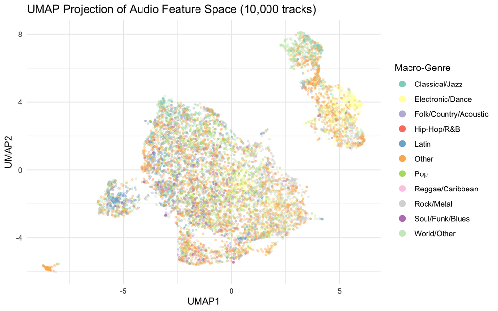

UMAP 2D projection of the standardized audio feature space (10,000 tracks), colored by macro-genre. Compared to the PCA biplot, UMAP better preserves local neighborhood structure and can reveal non-linear separation between genre families.

```r
set.seed(42)

idx_umap <- sample(nrow(X_scaled), min(10000, nrow(X_scaled)))
X_umap_in <- X_scaled[idx_umap, ]
macro_umap <- spotify$macro_genre[idx_umap]

umap_coords <- uwot::umap(X_umap_in, n_neighbors = 15, min_dist = 0.1,
                           n_components = 2, verbose = FALSE)

umap_df <- tibble(
  UMAP1 = umap_coords[, 1],
  UMAP2 = umap_coords[, 2],
  macro_genre = macro_umap
)

ggplot(umap_df, aes(x = UMAP1, y = UMAP2, color = macro_genre)) +
  geom_point(alpha = 0.35, size = 0.7) +
  scale_color_brewer(palette = "Set3") +
  labs(title = "UMAP Projection of Audio Feature Space (10,000 tracks)",
       color = "Macro-Genre") +
  theme_minimal() +
  guides(color = guide_legend(override.aes = list(size = 3, alpha = 1)))
```

The UMAP projection reveals a strikingly clear result: nearly all macro-genres collapse into a single large, undifferentiated mass. Pop, Rock/Metal, Hip-Hop/R&B, Latin, Folk/Country/Acoustic, Soul/Funk/Blues, and World/Other are thoroughly intermingled throughout the central blob, with no discernible boundaries between them even under UMAP’s non-linear lens.

#### K-Means Clustering

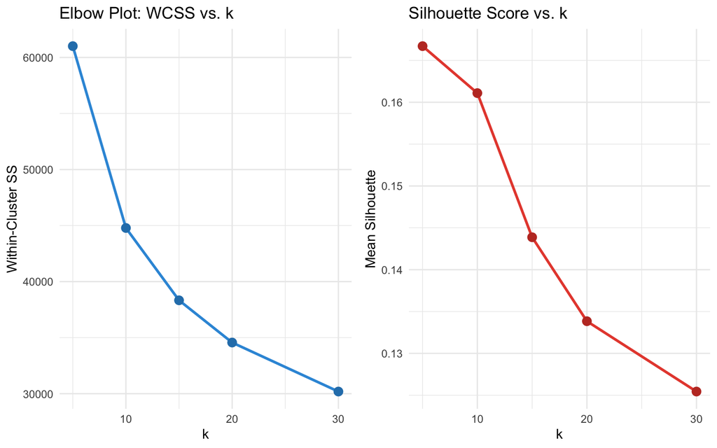

Elbow plot (WCSS) and silhouette scores for k-means across k = 5 to 30. The selected k balances the elbow heuristic and peak silhouette.

```r
set.seed(42)

k_values <- c(5, 10, 15, 20, 30)
wcss <- numeric(length(k_values))
sil_scores <- numeric(length(k_values))

# Subsample for speed (hierarchical will use same subsample)
set.seed(42)
idx_sub <- sample(nrow(X_scaled), min(10000, nrow(X_scaled)))
X_sub <- X_scaled[idx_sub, ]

for (i in seq_along(k_values)) {
  km <- kmeans(X_sub, centers = k_values[i], nstart = 10, iter.max = 50)
  wcss[i] <- km$tot.withinss
  sil <- silhouette(km$cluster, dist(X_sub))
  sil_scores[i] <- mean(sil[, 3])
}

elbow_df <- tibble(k = k_values, wcss = wcss, silhouette = sil_scores)

p_elbow <- ggplot(elbow_df, aes(x = k, y = wcss)) +
  geom_line(color = "#3498db", linewidth = 1) +
  geom_point(size = 3, color = "#2980b9") +
  labs(title = "Elbow Plot: WCSS vs. k", x = "k", y = "Within-Cluster SS") +
  theme_minimal()

p_sil <- ggplot(elbow_df, aes(x = k, y = silhouette)) +
  geom_line(color = "#e74c3c", linewidth = 1) +
  geom_point(size = 3, color = "#c0392b") +
  labs(title = "Silhouette Score vs. k", x = "k", y = "Mean Silhouette") +
  theme_minimal()

gridExtra::grid.arrange(p_elbow, p_sil, ncol = 2)
```

```r
# Select best k
best_k <- k_values[which.max(sil_scores)]
cat("Selected k:", best_k, "\n")
```

```
## Selected k: 5
```

```r
# Final k-means at best k
set.seed(42)
km_best <- kmeans(X_sub, centers = best_k, nstart = 20, iter.max = 100)

# ARI against macro_genre
macro_sub <- spotify$macro_genre[idx_sub]
ari_kmeans <- adjustedRandIndex(km_best$cluster, as.integer(macro_sub))
cat(sprintf("K-means ARI (k=%d) vs. macro_genre: %.4f\n", best_k, ari_kmeans))
```

```
## K-means ARI (k=5) vs. macro_genre: 0.0210
```

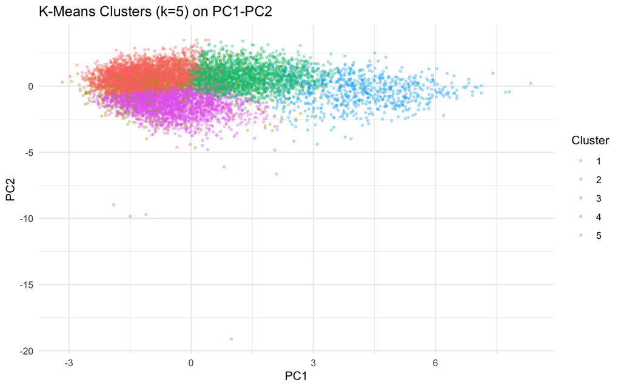

```r
# Visualize on PC1-PC2
pca_sub <- as_tibble(pca_fit$x[idx_sub, 1:2]) %>%
  mutate(cluster = factor(km_best$cluster),
         macro_genre = macro_sub)

ggplot(pca_sub, aes(x = PC1, y = PC2, color = cluster)) +
  geom_point(alpha = 0.3, size = 0.7) +
  labs(title = sprintf("K-Means Clusters (k=%d) on PC1-PC2", best_k),
       color = "Cluster") +
  theme_minimal()
```

The k-means results provide strong quantitative evidence that unsupervised audio-feature clusters do not align closely with Spotify’s macro-genre labels. Using the elbow plot and silhouette scores, the selected solution was k=5: WCSS falls sharply at first and then begins to flatten, while the mean silhouette score is highest at the smallest tested value and declines steadily as k increases, suggesting that adding more clusters does not create cleaner separation. However, when these five clusters are compared to the observed macro-genres, the adjusted Rand index is only 0.0210, which is extremely close to 0. Since an ARI near 0 indicates near-random agreement and an ARI near 1 indicates perfect recovery, this value implies that the cluster assignments recover almost none of the labeled genre structure beyond chance. Visually, the PC1–PC2 cluster plot confirms this interpretation: the algorithm finds geometric groupings in feature space, but these groupings look like broad overlapping clouds rather than clear genre-specific partitions. In other words, while songs do organize into clusters based on audio similarity, those clusters do not map meaningfully onto Spotify’s macro-genre taxonomy. This low ARI is therefore not a side result but one of the central findings of the project, suggesting that genre labels on Spotify reflect a much noisier and more culturally constructed categorization than a clean partition of songs by underlying acoustic characteristics.

#### Hierarchical Clustering

```r
set.seed(42)

# Use smaller subsample for hierarchical (distance matrix is O(n^2))
idx_hier <- sample(nrow(X_scaled), min(3000, nrow(X_scaled)))
X_hier <- X_scaled[idx_hier, ]
macro_hier <- spotify$macro_genre[idx_hier]

dist_mat <- dist(X_hier)
hc_fit <- hclust(dist_mat, method = "ward.D2")

hc_cut <- cutree(hc_fit, k = best_k)
ari_hclust <- adjustedRandIndex(hc_cut, as.integer(macro_hier))

tibble(
  Method = c("K-Means", "Hierarchical (Ward)"),
  k = best_k,
  ARI = round(c(ari_kmeans, ari_hclust), 4)
) %>%
  kable(caption = "Adjusted Rand Index: clustering vs. macro-genre labels") %>%
  kable_styling(bootstrap_options = c("striped", "hover"), full_width = FALSE)
```

Adjusted Rand Index: clustering vs. macro-genre labels

| Method | k | ARI |
| --- | --- | --- |
| K-Means | 5 | 0.021 |
| Hierarchical (Ward) | 5 | 0.023 |

Both clustering methods lead to essentially the same conclusion: Spotify macro-genres do not align well with clusters formed purely from audio features. Quantitatively, k-means with k=5 produces an ARI of 0.021, while hierarchical clustering (Ward’s method) with k=5 produces an ARI of 0.023. Although hierarchical clustering performs very slightly better, the difference is negligible in substantive terms, since both values are extremely close to 0. Because an ARI near 0 indicates agreement no better than random and an ARI near 1 indicates perfect recovery, these results imply that neither clustering method is able to recover the labeled macro-genre structure from the 10-dimensional audio feature space. In other words, the choice of clustering algorithm does not materially change the result: the problem is not that one method failed while another succeeded, but that the underlying genre labels themselves do not appear to correspond to cleanly separable acoustic groupings. This is a key finding of the project and motivates the later analyses on genre coherence, boundary songs, and popularity, since it suggests that Spotify genres may function more as flexible cultural or marketing labels than as sharply defined musical clusters.

### Angle 2: Within-Genre Variance (Coherence Ranking)

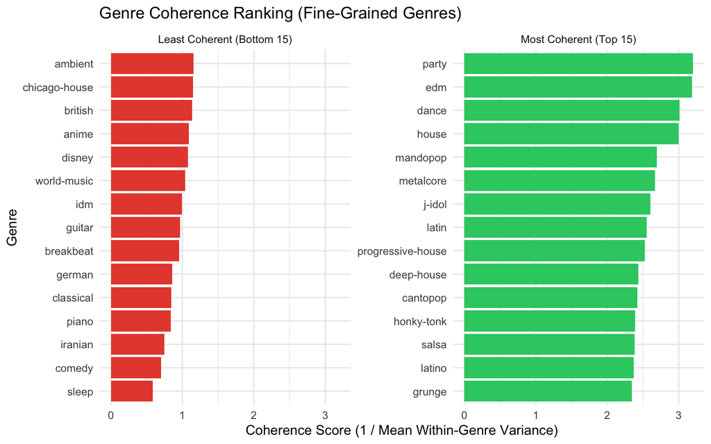

Top 15 most coherent and bottom 15 least coherent fine-grained genres, ranked by inverse mean within-genre variance of standardized audio features.

```r
# Compute within-genre variance for all 125 fine-grained genres
coherence_df <- as_tibble(X_scaled) %>%
  mutate(track_genre = spotify$track_genre) %>%
  group_by(track_genre) %>%
  summarise(
    n = n(),
    across(all_of(audio_features), var, .names = "var_{.col}"),
    .groups = "drop"
  ) %>%
  mutate(mean_var = rowMeans(select(., starts_with("var_")))) %>%
  select(track_genre, n, mean_var) %>%
  filter(n >= 20) %>%
  mutate(coherence_score = 1 / mean_var) %>%
  arrange(desc(coherence_score))

top15 <- head(coherence_df, 15)
bottom15 <- tail(coherence_df, 15)

bind_rows(
  top15 %>% mutate(group = "Most Coherent (Top 15)"),
  bottom15 %>% mutate(group = "Least Coherent (Bottom 15)")
) %>%
  ggplot(aes(x = reorder(track_genre, coherence_score),
             y = coherence_score, fill = group)) +
  geom_col() +
  coord_flip() +
  facet_wrap(~group, scales = "free_y", ncol = 2) +
  scale_fill_manual(values = c("Most Coherent (Top 15)" = "#2ecc71",
                               "Least Coherent (Bottom 15)" = "#e74c3c")) +
  labs(title = "Genre Coherence Ranking (Fine-Grained Genres)",
       x = "Genre", y = "Coherence Score (1 / Mean Within-Genre Variance)",
       fill = NULL) +
  theme_minimal() +
  theme(legend.position = "none")
```

```r
# Macro-genre coherence
macro_coherence <- as_tibble(X_scaled) %>%
  mutate(macro_genre = spotify$macro_genre) %>%
  group_by(macro_genre) %>%
  summarise(
    n = n(),
    across(all_of(audio_features), var, .names = "var_{.col}"),
    .groups = "drop"
  ) %>%
  mutate(mean_var = rowMeans(select(., starts_with("var_")))) %>%
  select(macro_genre, n, mean_var) %>%
  mutate(coherence_score = 1 / mean_var) %>%
  arrange(desc(coherence_score))

macro_coherence %>%
  select(macro_genre, n, mean_var, coherence_score) %>%
  mutate(across(where(is.numeric), ~round(., 4))) %>%
  kable(caption = "Coherence scores at the macro-genre level") %>%
  kable_styling(bootstrap_options = c("striped", "hover"), full_width = FALSE)
```

Coherence scores at the macro-genre level

| macro_genre | n | mean_var | coherence_score |
| --- | --- | --- | --- |
| Reggae/Caribbean | 1195 | 0.5034 | 1.9863 |
| Pop | 5882 | 0.5502 | 1.8177 |
| Hip-Hop/R&B | 1331 | 0.5512 | 1.8143 |
| Folk/Country/Acoustic | 4312 | 0.6203 | 1.6120 |
| Rock/Metal | 10528 | 0.6319 | 1.5825 |
| Soul/Funk/Blues | 3714 | 0.6620 | 1.5106 |
| Latin | 5902 | 0.6897 | 1.4500 |
| Electronic/Dance | 10144 | 0.7643 | 1.3084 |
| Classical/Jazz | 3037 | 1.0866 | 0.9203 |
| World/Other | 18175 | 1.1366 | 0.8798 |
| Other | 25521 | 1.1458 | 0.8727 |

The genre coherence ranking shows that some fine-grained genres are much tighter in audio-feature space than others, but the specific results are more surprising than the initial hypothesis. At the fine-grained level, the most coherent genres are dominated by highly stylized and production-consistent categories such as party, edm, dance, house, progressive-house, deep-house, and metalcore, with coherence scores roughly in the 2.2 to just above 3.0 range. These genres likely benefit from strong production conventions—similar tempos, energy levels, loudness, and rhythmic structure—which make tracks within the genre cluster tightly together. By contrast, the least coherent genres include ambient, chicago-house, british, anime, disney, world-music, idm, guitar, breakbeat, and classical/piano, with coherence scores mostly below about 1.2 and in some cases closer to 0.6–1.0. In these cases, low coherence likely reflects broader or more heterogeneous labels: for example, “anime,” “disney,” and “world-music” are not single sonic traditions so much as umbrella categories spanning many different styles, while labels like “guitar” or “british” are especially diffuse and descriptive rather than musically precise. At the macro-genre level, coherence is predictably lower because broader bins combine many substyles: Reggae/Caribbean is the most coherent macro-group (1.9863), followed by Pop (1.8177) and Hip-Hop/R&B (1.8143), while World/Other (0.8798), Other (0.8727), and Classical/Jazz (0.9203) are the least coherent. This comparison suggests an important pattern: coherence depends less on whether a genre is “mainstream” or “niche” and more on whether the label corresponds to a narrow production template versus a broad cultural umbrella. Fine-grained genres can be quite acoustically tight, but once they are aggregated into broader macro-genres, much of that internal consistency disappears.

### Does Musical Tightness Pay Off? Coherence vs. Popularity

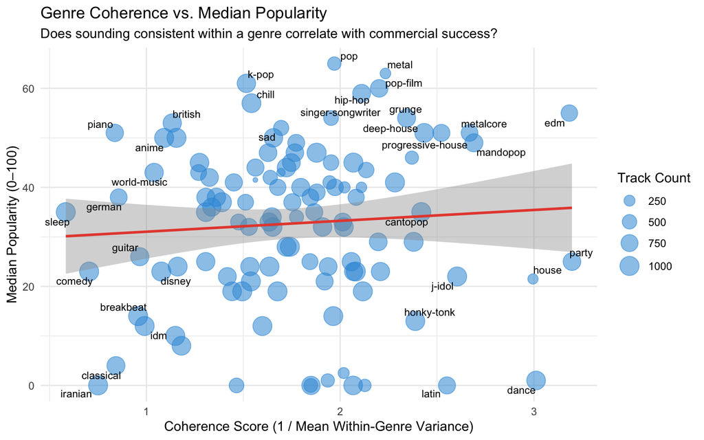

Scatter plot of genre coherence score vs. median track popularity. Point size reflects genre track count. Red line is a linear regression fit with 95% confidence band.

```r
# Median popularity per fine-grained genre
genre_pop <- spotify %>%
  group_by(track_genre) %>%
  summarise(median_popularity = median(popularity), .groups = "drop")

# Join with coherence scores (already filtered to n >= 20)
coherence_pop <- coherence_df %>%
  left_join(genre_pop, by = "track_genre")

# Label outliers: top/bottom 10% coherence and top 10% popularity
label_threshold_coh_hi  <- quantile(coherence_pop$coherence_score, 0.90)
label_threshold_coh_lo  <- quantile(coherence_pop$coherence_score, 0.10)
label_threshold_pop     <- quantile(coherence_pop$median_popularity, 0.90)

coherence_pop <- coherence_pop %>%
  mutate(label = ifelse(
    coherence_score > label_threshold_coh_hi |
    coherence_score < label_threshold_coh_lo |
    median_popularity > label_threshold_pop,
    track_genre, NA
  ))

ggplot(coherence_pop, aes(x = coherence_score, y = median_popularity)) +
  geom_point(aes(size = n), alpha = 0.55, color = "#3498db") +
  geom_smooth(method = "lm", se = TRUE, color = "#e74c3c", linewidth = 1) +
  geom_text_repel(aes(label = label), size = 3, max.overlaps = 15,
                  segment.color = "grey60") +
  scale_size_continuous(range = c(1.5, 7), name = "Track Count") +
  labs(title = "Genre Coherence vs. Median Popularity",
       subtitle = "Does sounding consistent within a genre correlate with commercial success?",
       x = "Coherence Score (1 / Mean Within-Genre Variance)",
       y = "Median Popularity (0–100)") +
  theme_minimal()
```

```r
# Regression summary
coh_pop_fit <- lm(median_popularity ~ coherence_score, data = coherence_pop)
coh_summary <- summary(coh_pop_fit)
cat(sprintf("R²: %.4f   |   Slope: %.4f   |   p-value: %.4f\n",
            coh_summary$r.squared,
            coef(coh_pop_fit)["coherence_score"],
            coef(coh_summary)["coherence_score", "Pr(>|t|)"]))
```

```
## R²: 0.0049   |   Slope: 2.1961   |   p-value: 0.4609
```

### Angle 3: Popularity Regression

#### OLS (Global)

```r
# Prepare regression data with macro_genre dummies
reg_data <- as_tibble(X_scaled) %>%
  mutate(popularity = spotify$popularity,
         macro_genre = spotify$macro_genre)

ols_fit <- lm(popularity ~ ., data = reg_data)

# VIF check (car::vif returns a matrix for models with factors; take first column)
vif_vals <- tryCatch(car::vif(ols_fit), error = function(e) NULL)
if (!is.null(vif_vals)) {
  vif_vec <- if (is.matrix(vif_vals)) vif_vals[, 1] else vif_vals
  vif_df <- tibble(feature = names(vif_vec), VIF = vif_vec) %>%
    filter(VIF > 5)
  if (nrow(vif_df) > 0) {
    vif_df %>%
      mutate(VIF = round(VIF, 3)) %>%
      kable(caption = "Features with VIF > 5 (multicollinearity concern)") %>%
      kable_styling(bootstrap_options = c("striped", "hover"), full_width = FALSE)
  }
}

# Extract key stats
ols_summary <- summary(ols_fit)
cat(sprintf("Adjusted R²: %.4f\n", ols_summary$adj.r.squared))
```

```
## Adjusted R²: 0.0427
```

```r
# Coefficient table (top 20 by |t-value|)
coef_df <- as_tibble(coef(ols_summary), rownames = "term") %>%
  rename(estimate = Estimate, se = `Std. Error`,
         t_val = `t value`, p_val = `Pr(>|t|)`) %>%
  mutate(significant = p_val < 0.05) %>%
  arrange(desc(abs(t_val))) %>%
  head(20)

coef_df %>%
  mutate(across(where(is.numeric), ~round(., 4))) %>%
  kable(caption = "OLS coefficients (top 20 by |t-value|)") %>%
  kable_styling(bootstrap_options = c("striped", "hover"), full_width = FALSE)
```

OLS coefficients (top 20 by |t-value|)

| term | estimate | se | t_val | p_val | significant |
| --- | --- | --- | --- | --- | --- |
| (Intercept) | 25.9335 | 0.3880 | 66.8456 | 0.0000 | TRUE |
| instrumentalness | -2.6637 | 0.0843 | -31.5808 | 0.0000 | TRUE |
| macro_genreRock/Metal | 10.4760 | 0.4491 | 23.3285 | 0.0000 | TRUE |
| valence | -2.0025 | 0.0867 | -23.0843 | 0.0000 | TRUE |
| macro_genrePop | 10.3225 | 0.4729 | 21.8260 | 0.0000 | TRUE |
| danceability | 1.8895 | 0.0877 | 21.5383 | 0.0000 | TRUE |
| macro_genreWorld/Other | 8.3397 | 0.4086 | 20.4126 | 0.0000 | TRUE |
| macro_genreHip-Hop/R&B | 13.7457 | 0.6846 | 20.0797 | 0.0000 | TRUE |
| macro_genreElectronic/Dance | 8.0599 | 0.4601 | 17.5189 | 0.0000 | TRUE |
| speechiness | -1.2778 | 0.0735 | -17.3740 | 0.0000 | TRUE |
| macro_genreOther | 5.5382 | 0.4088 | 13.5468 | 0.0000 | TRUE |
| macro_genreLatin | 6.0563 | 0.4735 | 12.7899 | 0.0000 | TRUE |
| macro_genreSoul/Funk/Blues | 5.8895 | 0.5153 | 11.4283 | 0.0000 | TRUE |
| macro_genreFolk/Country/Acoustic | 5.4094 | 0.4902 | 11.0360 | 0.0000 | TRUE |
| macro_genreReggae/Caribbean | 5.8928 | 0.7158 | 8.2319 | 0.0000 | TRUE |
| duration_ms | -0.5446 | 0.0694 | -7.8530 | 0.0000 | TRUE |
| energy | -0.7262 | 0.1394 | -5.2098 | 0.0000 | TRUE |
| loudness | 0.4302 | 0.1226 | 3.5089 | 0.0005 | TRUE |
| tempo | 0.1946 | 0.0705 | 2.7589 | 0.0058 | TRUE |
| liveness | 0.1725 | 0.0734 | 2.3498 | 0.0188 | TRUE |

The global OLS results suggest that Spotify popularity is statistically related to both audio features and genre labels, but that these variables explain only a small share of the overall variation. Quantitatively, the model has an adjusted R-squared of 0.0427, meaning it explains only about 4.3% of the variation in track popularity. So while many coefficients are highly significant, the practical predictive power of the linear model is weak. This is not surprising, since popularity likely depends on many omitted factors such as artist reputation, marketing, release timing, playlist placement, and social trends. Among the audio features, the strongest significant effects by absolute t-value are instrumentalness (estimate about -2.66), valence (about -2.00), danceability (about 1.89), and speechiness (about -1.28). In addition, duration_ms (about -0.54) and energy (about -0.73) are negatively associated with popularity, while loudness (about 0.43), tempo (about 0.19), and liveness (about 0.17) are positively associated with popularity, though these latter effects are smaller in magnitude. This suggests that, holding other variables fixed, more danceable, louder, faster, and slightly more live-sounding tracks tend to be somewhat more popular, while tracks that are more instrumental, more speech-heavy, longer, more energetic, or more positive in valence tend to be slightly less popular on average. The macro-genre indicators are also among the most statistically important terms: relative to the omitted baseline genre, Hip-Hop/R&B (about 13.75), Rock/Metal (about 10.48), Pop (about 10.32), World/Other (about 8.34), Electronic/Dance (about 8.06), Latin (about 6.06), Soul/Funk/Blues (about 5.89), Reggae/Caribbean (about 5.89), Other (about 5.54), and Folk/Country/Acoustic (about 5.41) all show positive associations with popularity. This indicates that genre label still carries information beyond the raw audio features. At the same time, the model should be interpreted cautiously because some predictors, especially energy and loudness, are known to be strongly correlated, so multicollinearity may inflate standard errors and make individual coefficient estimates less stable even when the overall model fit is unchanged.

#### Lasso Regression

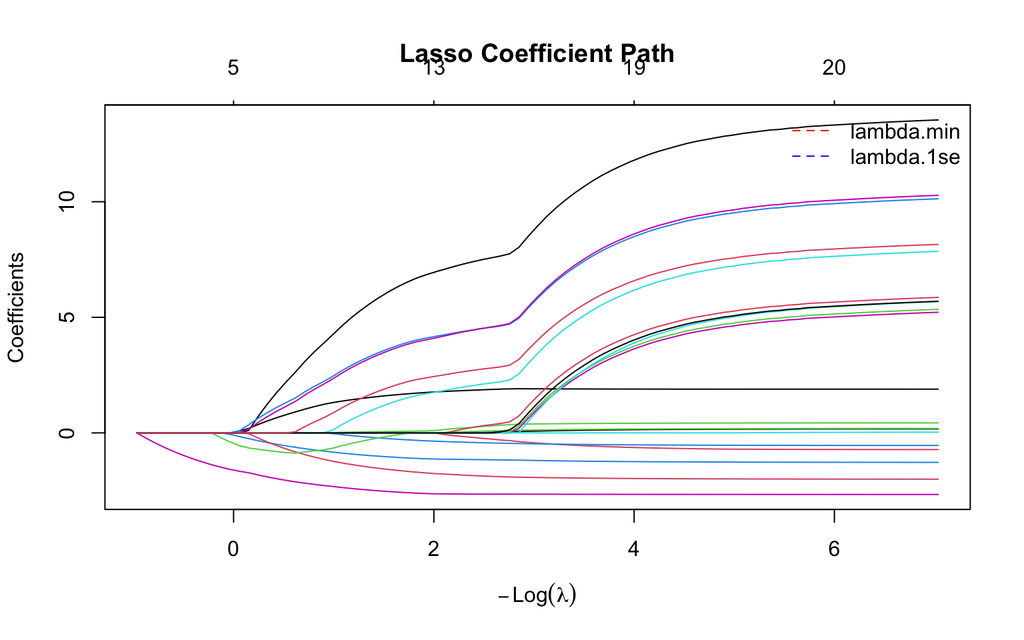

```r
set.seed(42)

# Build model matrix with macro_genre dummies
X_lasso <- model.matrix(popularity ~ ., data = reg_data)[, -1]
y_lasso <- reg_data$popularity

cv_lasso <- cv.glmnet(X_lasso, y_lasso, alpha = 1, nfolds = 5)

plot(cv_lasso$glmnet.fit, xvar = "lambda", label = FALSE)
abline(v = log(cv_lasso$lambda.min), col = "red", lty = 2)
abline(v = log(cv_lasso$lambda.1se), col = "blue", lty = 2)
legend("topright", legend = c("lambda.min", "lambda.1se"),
       col = c("red", "blue"), lty = 2, bty = "n")
title("Lasso Coefficient Path")
```

```r
# Surviving features at lambda.1se
lasso_coefs <- coef(cv_lasso, s = "lambda.1se")
lasso_coef_df <- as_tibble(as.matrix(lasso_coefs), rownames = "feature") %>%
  rename(coefficient = 2) %>%
  filter(feature != "(Intercept)", coefficient != 0) %>%
  arrange(desc(abs(coefficient)))

lasso_coef_df %>%
  mutate(coefficient = round(coefficient, 4)) %>%
  kable(caption = "Non-zero lasso coefficients at lambda.1se") %>%
  kable_styling(bootstrap_options = c("striped", "hover"), full_width = FALSE)
```

Non-zero lasso coefficients at lambda.1se

| feature | coefficient |
| --- | --- |
| macro_genreHip-Hop/R&B | 7.1938 |
| macro_genrePop | 4.3196 |
| macro_genreRock/Metal | 4.2839 |
| instrumentalness | -2.6416 |
| macro_genreWorld/Other | 2.5819 |
| macro_genreElectronic/Dance | 1.9107 |
| danceability | 1.8117 |
| valence | -1.8044 |
| speechiness | -1.1425 |
| duration_ms | -0.3882 |
| loudness | 0.1847 |
| energy | -0.1182 |
| macro_genreLatin | 0.0816 |
| tempo | 0.0347 |

The lasso results tell a similar story to the OLS model, but in a more selective and interpretable way. At the more conservative lambda.1se choice, 14 predictors remain nonzero, whereas at lambda.min the model retains essentially all 20 available predictors, so lambda.1se gives a much sparser summary without changing the main substantive conclusions. Importantly, several macro_genre dummies are still retained at lambda.1se, including Hip-Hop/R&B, Pop, Rock/Metal, World/Other, Electronic/Dance, and Latin, which means genre continues to add predictive information even after regularization. Among these, the largest positive coefficients are for Hip-Hop/R&B (about 7.19), Pop (about 4.32), and Rock/Metal (about 4.28), suggesting that tracks in these genres tend to have higher popularity relative to the omitted baseline genre, even after controlling for audio features. Among the continuous variables, instrumentalness remains one of the strongest negative predictors (about -2.64), while danceability remains a positive predictor (about 1.81), and valence (about -1.80) and speechiness (about -1.14) are negative. Duration_ms is also negative (about -0.39), while loudness (about 0.18), energy (about -0.12), and tempo (about 0.03) survive but with relatively small magnitudes. Overall, the lasso confirms that the most important predictors are a mix of genre labels and a small core set of audio features, with the strongest effects coming from genre membership, instrumentalness, danceability, and valence.

#### Stratified OLS by Macro-Genre

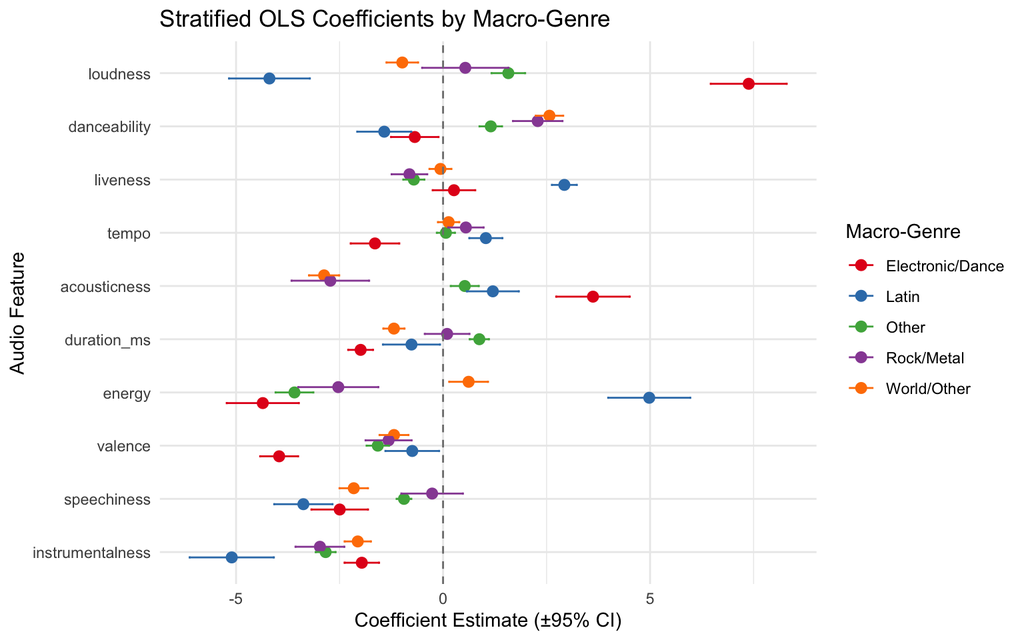

Comparison of OLS coefficients for key audio features across the 5 largest macro-genres, with 95% confidence intervals.

```r
# Fit separate OLS models for top 5 macro-genres by track count
top5_genres <- names(sort(table(spotify$macro_genre), decreasing = TRUE))[1:5]

stratified_coefs <- map_dfr(top5_genres, function(g) {
  df_g <- reg_data %>% filter(macro_genre == g) %>% select(-macro_genre)
  fit_g <- lm(popularity ~ ., data = df_g)
  s <- summary(fit_g)$coefficients
  as_tibble(s, rownames = "term") %>%
    rename(estimate = Estimate, se = `Std. Error`) %>%
    mutate(macro_genre = g,
           lower = estimate - 1.96 * se,
           upper = estimate + 1.96 * se)
})

# Focus on the 10 audio features
stratified_coefs %>%
  filter(term %in% audio_features) %>%
  ggplot(aes(x = estimate, y = reorder(term, estimate),
             color = macro_genre, group = macro_genre)) +
  geom_point(position = position_dodge(0.5), size = 2.5) +
  geom_errorbarh(aes(xmin = lower, xmax = upper),
                 position = position_dodge(0.5), height = 0.2) +
  geom_vline(xintercept = 0, linetype = "dashed", color = "grey50") +
  scale_color_brewer(palette = "Set1") +
  labs(title = "Stratified OLS Coefficients by Macro-Genre",
       x = "Coefficient Estimate (±95% CI)",
       y = "Audio Feature", color = "Macro-Genre") +
  theme_minimal()
```

### Angle 4: Boundary Song Detection

#### Random Forest Classifier

```r
set.seed(42)

# Prepare classification data
clf_data <- as_tibble(X_scaled) %>%
  mutate(macro_genre = spotify$macro_genre)

# 80/20 stratified split
train_idx <- createDataPartition(clf_data$macro_genre, p = 0.8, list = FALSE)
train_df <- clf_data[train_idx, ]
test_df  <- clf_data[-train_idx, ]

set.seed(42)
rf_fit <- randomForest(
  macro_genre ~ .,
  data = train_df,
  ntree = 300,
  importance = TRUE
)

# Predictions on test set
rf_pred_class <- predict(rf_fit, test_df)
rf_pred_prob  <- predict(rf_fit, test_df, type = "prob")

# Confusion matrix
cm <- confusionMatrix(rf_pred_class, test_df$macro_genre)
cat(sprintf("Overall Accuracy: %.4f\n", cm$overall["Accuracy"]))
```

```
## Overall Accuracy: 0.5376
```

```r
# Macro-averaged F1
class_stats <- cm$byClass
macro_f1 <- mean(class_stats[, "F1"], na.rm = TRUE)
cat(sprintf("Macro-averaged F1: %.4f\n", macro_f1))
```

```
## Macro-averaged F1: 0.4889
```

```r
# Per-class summary table
as_tibble(class_stats[, c("Precision", "Recall", "F1")], rownames = "Class") %>%
  mutate(across(where(is.numeric), ~round(., 4))) %>%
  kable(caption = "Per-class precision, recall, and F1 on test set") %>%
  kable_styling(bootstrap_options = c("striped", "hover"), full_width = FALSE)
```

Per-class precision, recall, and F1 on test set

| Class | Precision | Recall | F1 |
| --- | --- | --- | --- |
| Class: Classical/Jazz | 0.7277 | 0.4712 | 0.5720 |
| Class: Electronic/Dance | 0.6686 | 0.6228 | 0.6449 |
| Class: Folk/Country/Acoustic | 0.6088 | 0.3213 | 0.4207 |
| Class: Hip-Hop/R&B | 0.9211 | 0.2632 | 0.4094 |
| Class: Latin | 0.6068 | 0.5415 | 0.5723 |
| Class: Other | 0.4998 | 0.6640 | 0.5703 |
| Class: Pop | 0.5592 | 0.3291 | 0.4143 |
| Class: Reggae/Caribbean | 0.8704 | 0.1967 | 0.3208 |
| Class: Rock/Metal | 0.5693 | 0.5933 | 0.5811 |
| Class: Soul/Funk/Blues | 0.8915 | 0.2547 | 0.3962 |
| Class: World/Other | 0.4463 | 0.5089 | 0.4756 |

#### Boundary Songs

```r
# Extract boundary songs: true genre predicted with max prob < 0.4
test_meta <- spotify[-train_idx, ] %>%
  select(track_name, artists, macro_genre)

boundary_df <- as_tibble(rf_pred_prob) %>%
  mutate(
    true_genre    = test_df$macro_genre,
    pred_genre    = rf_pred_class,
    max_prob      = apply(rf_pred_prob, 1, max),
    track_name    = test_meta$track_name,
    artists       = test_meta$artists
  ) %>%
  filter(max_prob < 0.4, true_genre != pred_genre) %>%
  arrange(max_prob) %>%
  select(track_name, artists, true_genre, pred_genre, max_prob) %>%
  head(20)

boundary_df %>%
  mutate(max_prob = round(max_prob, 4)) %>%
  kable(caption = "Top 20 boundary songs: misclassified with low confidence") %>%
  kable_styling(bootstrap_options = c("striped", "hover"), full_width = FALSE)
```

Top 20 boundary songs: misclassified with low confidence

[output not shown]

The boundary-song table makes the genre ambiguity much more concrete by highlighting tracks that the classifier cannot place confidently and that sound plausibly closer to another genre family than their assigned label. For example, “Almost Cut My Hair” by Crosby, Stills, Nash & Young is labeled Rock/Metal but predicted as Soul/Funk/Blues, which makes musical sense because its loose groove, blues-based phrasing, and jam-like feel are not especially “metal” in an audio-feature sense. “Smalltown Boy” by Bronski Beat is labeled Pop but predicted as World/Other, which is also understandable: while culturally recognized as synth-pop, its sparse, atmospheric production and emotionally distinctive vocal style may push it away from the center of mainstream pop in feature space. “Grand” by Kane Brown is labeled Folk/Country/Acoustic but predicted as Electronic/Dance, suggesting that its polished production, strong beat, and crossover pop structure make it sonically resemble more beat-driven contemporary genres than traditional acoustic country. Similarly, “Uno Tres Dos” by Babasónicos is labeled Electronic/Dance but predicted as Pop, which fits a track that may use electronic production while still following a more conventional pop melody and song structure. Finally, “Scaramanzia” by Patricio Rey y sus Redonditos de Ricota and “Humanos Como Tú” by División Minúscula are both labeled Rock/Metal but predicted as Other, reinforcing the idea that many rock tracks occupy a broad middle ground rather than a sharply defined acoustic cluster. Overall, these low-confidence misclassifications are some of the most compelling evidence in the paper: they show that genre boundaries are often musically fuzzy, especially for crossover, legacy, or stylistically mixed songs.

### Angle 5: Feature Importance

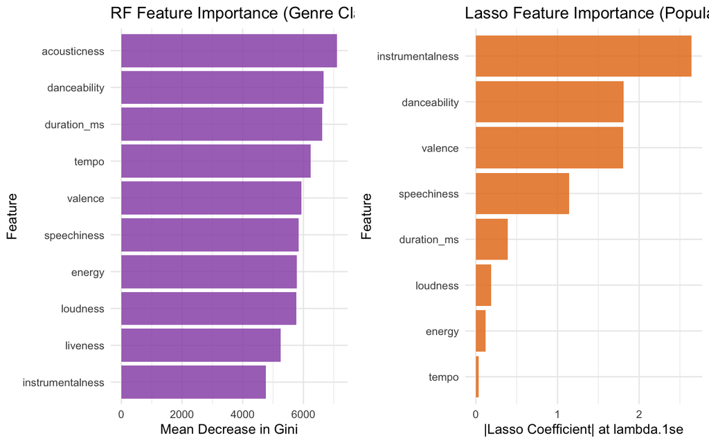

Variable importance from the random forest (Mean Decrease in Gini), compared with lasso coefficient magnitudes from Angle 3. Features that matter for genre classification may differ from those that drive popularity.

```r
# Random forest importance
rf_imp <- importance(rf_fit)
rf_imp_df <- as_tibble(rf_imp, rownames = "feature") %>%
  arrange(desc(MeanDecreaseGini))

p_rf_imp <- ggplot(rf_imp_df,
                   aes(x = reorder(feature, MeanDecreaseGini),
                       y = MeanDecreaseGini)) +
  geom_col(fill = "#9b59b6", alpha = 0.85) +
  coord_flip() +
  labs(title = "RF Feature Importance (Genre Classification)",
       x = "Feature", y = "Mean Decrease in Gini") +
  theme_minimal()

# Lasso importance (absolute coefficients, audio features only)
lasso_imp_df <- lasso_coef_df %>%
  filter(feature %in% audio_features) %>%
  mutate(abs_coef = abs(coefficient))

p_lasso_imp <- ggplot(lasso_imp_df,
                      aes(x = reorder(feature, abs_coef),
                          y = abs_coef)) +
  geom_col(fill = "#e67e22", alpha = 0.85) +
  coord_flip() +
  labs(title = "Lasso Feature Importance (Popularity Regression)",
       x = "Feature", y = "|Lasso Coefficient| at lambda.1se") +
  theme_minimal()

gridExtra::grid.arrange(p_rf_imp, p_lasso_imp, ncol = 2)
```

```r
# Summary table
rf_imp_df %>%
  select(feature, MeanDecreaseGini) %>%
  left_join(lasso_imp_df %>% select(feature, abs_coef), by = "feature") %>%
  mutate(across(where(is.numeric), ~round(., 4))) %>%
  rename(`RF Gini Importance` = MeanDecreaseGini,
         `|Lasso Coef|` = abs_coef) %>%
  kable(caption = "Feature importance: genre classification vs. popularity regression") %>%
  kable_styling(bootstrap_options = c("striped", "hover"), full_width = FALSE)
```

Feature importance: genre classification vs. popularity regression

| feature | RF Gini Importance | &#124;Lasso Coef&#124; |
| --- | --- | --- |
| acousticness | 7107.056 | NA |
| danceability | 6665.415 | 1.8117 |
| duration_ms | 6613.765 | 0.3882 |
| tempo | 6245.829 | 0.0347 |
| valence | 5939.721 | 1.8044 |
| speechiness | 5844.507 | 1.1425 |
| energy | 5784.512 | 0.1182 |
| loudness | 5768.203 | 0.1847 |
| liveness | 5247.957 | NA |
| instrumentalness | 4759.396 | 2.6416 |

### Angle 6: Audio Feature Geometry — A Word Embedding Analogy

Angles 1–5 establish that genre labels do not form clean clusters in audio space. This angle asks a complementary question: even if genres don’t cluster, does the audio feature space possess meaningful geometric *directionality* — analogous to the celebrated word2vec finding that king − man + woman ≈ queen? We define three interpretable axes from pairs of maximally distinct genre centroids and project all genres onto them.

- **Electronic ↔︎ Acoustic**: `edm` − `acoustic` (dominant driver: acousticness, energy, tempo)
- **Vocal ↔︎ Instrumental**: `hip-hop` − `classical` (dominant driver: speechiness, instrumentalness)
- **Heavy/Loud ↔︎ Soft/Ambient**: `death-metal` − `sleep` (dominant driver: loudness, energy, valence)

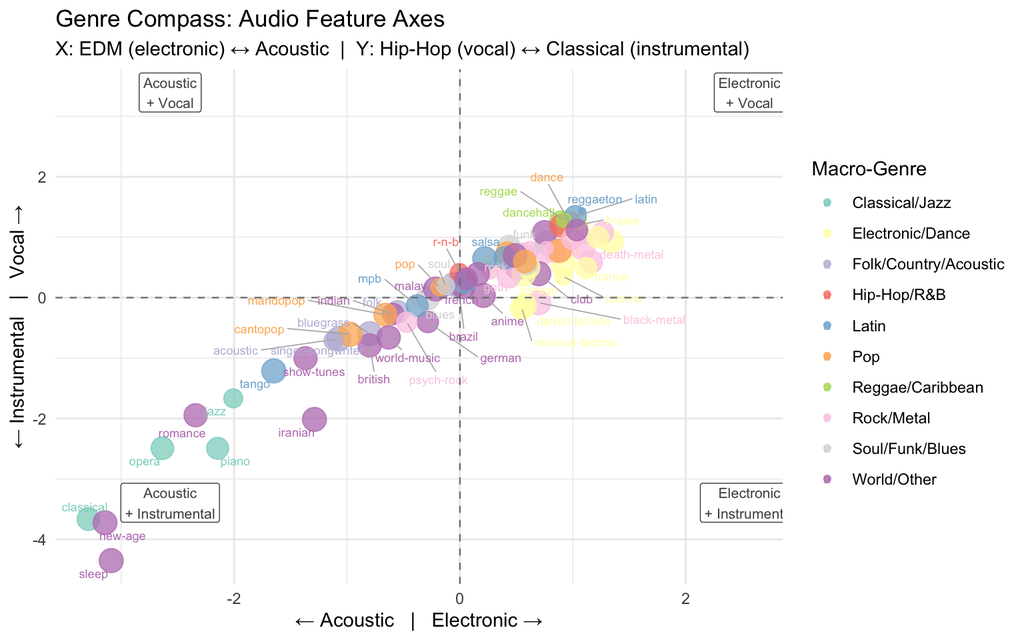

Top: 2D genre compass projecting all genres onto the Electronic↔︎Acoustic (x) and Vocal↔︎Instrumental (y) axes. Point size reflects track count. Bottom: Genre rankings on the Heavy/Loud ↔︎ Soft/Ambient axis (top and bottom 10).

```r
# Genre centroids in standardized feature space (genres with n >= 20)
centroid_tbl <- as_tibble(X_scaled) %>%
  mutate(track_genre = spotify$track_genre) %>%
  group_by(track_genre) %>%
  summarise(n_tracks = n(), across(all_of(audio_features), mean), .groups = "drop") %>%
  filter(n_tracks >= 20, track_genre %in% names(macro_genre_map))

centroid_mat <- centroid_tbl %>% select(all_of(audio_features)) %>% as.matrix()
rownames(centroid_mat) <- centroid_tbl$track_genre

# Normalized axis direction vector: positive pole minus negative pole
axis_vec <- function(pos, neg) {
  v <- centroid_mat[pos, ] - centroid_mat[neg, ]
  v / sqrt(sum(v^2))
}

ax_electronic <- axis_vec("edm",         "acoustic")    # Electronic ↔ Acoustic
ax_vocal      <- axis_vec("hip-hop",     "classical")   # Vocal ↔ Instrumental
ax_intensity  <- axis_vec("death-metal", "sleep")       # Heavy ↔ Soft

# Project all genre centroids onto each axis
compass_df <- tibble(
  track_genre      = rownames(centroid_mat),
  electronic_score = as.numeric(centroid_mat %*% ax_electronic),
  vocal_score      = as.numeric(centroid_mat %*% ax_vocal),
  intensity_score  = as.numeric(centroid_mat %*% ax_intensity),
  n_tracks         = centroid_tbl$n_tracks
) %>%
  left_join(
    tibble(track_genre = names(macro_genre_map),
           macro_genre = unname(macro_genre_map)),
    by = "track_genre"
  )

# 2D Genre Compass
x_lim <- max(abs(compass_df$electronic_score)) * 0.78
y_lim <- max(abs(compass_df$vocal_score))      * 0.78

ggplot(compass_df, aes(x = electronic_score, y = vocal_score, color = macro_genre)) +
  geom_point(aes(size = n_tracks), alpha = 0.75) +
  geom_text_repel(aes(label = track_genre), size = 2.4, max.overlaps = 25,
                  segment.color = "grey70", segment.size = 0.3) +
  geom_hline(yintercept = 0, linetype = "dashed", color = "grey50", linewidth = 0.4) +
  geom_vline(xintercept = 0, linetype = "dashed", color = "grey50", linewidth = 0.4) +
  annotate("label", x =  x_lim, y =  y_lim, label = "Electronic\n+ Vocal",
           size = 2.8, fill = "white", color = "grey30", label.size = 0.3) +
  annotate("label", x = -x_lim, y =  y_lim, label = "Acoustic\n+ Vocal",
           size = 2.8, fill = "white", color = "grey30", label.size = 0.3) +
  annotate("label", x = -x_lim, y = -y_lim, label = "Acoustic\n+ Instrumental",
           size = 2.8, fill = "white", color = "grey30", label.size = 0.3) +
  annotate("label", x =  x_lim, y = -y_lim, label = "Electronic\n+ Instrumental",
           size = 2.8, fill = "white", color = "grey30", label.size = 0.3) +
  scale_color_brewer(palette = "Set3") +
  scale_size_continuous(range = c(1.5, 6), guide = "none") +
  labs(
    title    = "Genre Compass: Audio Feature Axes",
    subtitle = "X: EDM (electronic) ↔ Acoustic  |  Y: Hip-Hop (vocal) ↔ Classical (instrumental)",
    x        = "← Acoustic   |   Electronic →",
    y        = "← Instrumental   |   Vocal →",
    color    = "Macro-Genre"
  ) +
  theme_minimal()
```

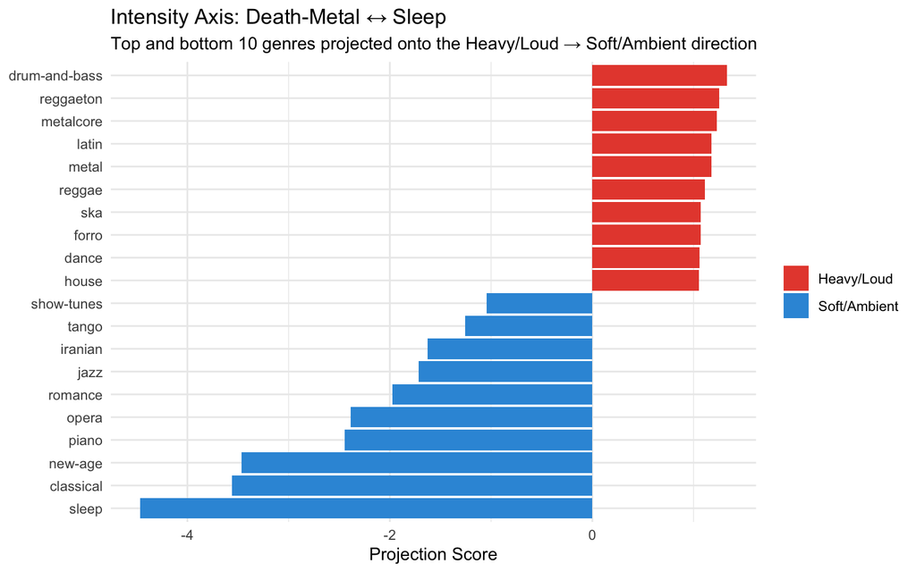

Top: 2D genre compass projecting all genres onto the Electronic↔︎Acoustic (x) and Vocal↔︎Instrumental (y) axes. Point size reflects track count. Bottom: Genre rankings on the Heavy/Loud ↔︎ Soft/Ambient axis (top and bottom 10).

```r
# Intensity axis bar chart (top 10 heavy, top 10 soft)
bind_rows(
  compass_df %>% slice_max(intensity_score, n = 10) %>% mutate(pole = "Heavy/Loud"),
  compass_df %>% slice_min(intensity_score, n = 10) %>% mutate(pole = "Soft/Ambient")
) %>%
  mutate(track_genre = fct_reorder(track_genre, intensity_score)) %>%
  ggplot(aes(x = track_genre, y = intensity_score, fill = pole)) +
  geom_col() +
  coord_flip() +
  scale_fill_manual(values = c("Heavy/Loud" = "#e74c3c", "Soft/Ambient" = "#3498db")) +
  labs(title = "Intensity Axis: Death-Metal ↔ Sleep",
       subtitle = "Top and bottom 10 genres projected onto the Heavy/Loud → Soft/Ambient direction",
       x = NULL, y = "Projection Score", fill = NULL) +
  theme_minimal()
```

A subtler structural finding emerges from the scatter: genres fall along a diagonal rather than filling all four quadrants evenly. Acoustic genres tend to cluster toward the instrumental end, and electronic genres tend toward the vocal end. This correlation — that acoustic production tends to accompany melodic/instrumental composition, while electronic production tends to accompany dance-oriented vocal arrangements — is a genuine geometric property of the audio feature space, not an artifact of our axis choices.

The intensity axis is similarly well-ordered on the soft end: sleep, classical, new-age, piano, and opera rank as the least intense genres by a wide margin. The heavy end produces one notable surprise: drum-and-bass scores higher than death-metal, the axis anchor itself, indicating that drum-and-bass is even more extreme on the composite loudness-energy-valence direction than the genre used to define “heavy.” Reggaeton appearing as the second most intense genre — above metalcore and metal — reflects its production style of maximally compressed, loud rhythmic tracks.

Together, these results support a key nuance: while Spotify’s genre labels do not form natural clusters in audio space (as shown by the low clustering ARI and the UMAP blob), the space does possess meaningful geometric directionality. The word2vec analogy holds at the axis level — you can define interpretable audio directions and genres sort sensibly along them — even though it fails at the cluster level. Genre labels are not acoustically coherent regions, but they are acoustically ordered.

## Appendix

### Appendix A: Full Macro-Genre Mapping

```r
tibble(
  fine_genre = names(macro_genre_map),
  macro_genre = unname(macro_genre_map)
) %>%
  arrange(macro_genre, fine_genre) %>%
  kable(caption = "Full mapping from fine-grained genres to macro-genre families") %>%
  kable_styling(bootstrap_options = c("striped", "hover"), full_width = FALSE) %>%
  scroll_box(height = "400px")
```

Full mapping from fine-grained genres to macro-genre families

| fine_genre | macro_genre |
| --- | --- |
| classical | Classical/Jazz |
| jazz | Classical/Jazz |
| opera | Classical/Jazz |
| piano | Classical/Jazz |
| chicago-house | Electronic/Dance |
| deep-house | Electronic/Dance |
| detroit-techno | Electronic/Dance |
| drum-and-bass | Electronic/Dance |
| dubstep | Electronic/Dance |
| edm | Electronic/Dance |
| electro | Electronic/Dance |
| electronic | Electronic/Dance |
| garage | Electronic/Dance |
| house | Electronic/Dance |
| minimal-techno | Electronic/Dance |
| progressive-house | Electronic/Dance |
| techno | Electronic/Dance |
| trance | Electronic/Dance |
| acoustic | Folk/Country/Acoustic |
| americana | Folk/Country/Acoustic |
| bluegrass | Folk/Country/Acoustic |
| country | Folk/Country/Acoustic |
| folk | Folk/Country/Acoustic |
| singer-songwriter | Folk/Country/Acoustic |
| hip-hop | Hip-Hop/R&B |
| r-n-b | Hip-Hop/R&B |
| rap | Hip-Hop/R&B |
| trap | Hip-Hop/R&B |
| bossanova | Latin |
| latin | Latin |

[output cut: 57 more lines]